# My Awesome Study About My Study Music

Author

Jasper Jansen

# Background

## What kind of music makes me lock-in?

In this report, I’m going to investigate to what type of music I study effectively. Recently, I have listened to 4 different albums of Tame Impala which have helped study, resulting in grades ranging from an F to an A.

## The albums in question.

- **Deadbeat (*2025*)**

[figure not shown]

- **The Slow Rush (*2020*)**

[figure not shown]

- **Currents (*2015*)**

[figure not shown]

- **Lonerism (*2012*)**

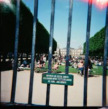

## Song listened most on repeat.

[video not shown]

## Lyrics that make you think.

> *Talk is cheap, but the words cut deep.*

> *Promises get old, they get hard to keep.*

**From Obsolete, in Deadbeat (*2025*)**

# Data analysis

Let’s get to business.

## Data source

First, all links for all 49 tracks divided over 4 albums were copied from Spotify (https://open.spotify.com), these links were then analysed with the website provided by our professor (https://music-analysis-server-552195150834.europe-west4.run.app/?&wtd=Bink96kwrpd8EUUf). This resulted in a list in chronological order with all the data required, exported in an Excel sheet. In this way, I created my own data set.

## Data preparation

The Excel sheet initially contained all the variables from the data in one column, although there were commas between the different variables. Using the function “Text from Columns” found under Data, all variables received their own column. However, one title had a comma included, making that observation invalid. After removing the comma from the title in row 38, and repeating the “Text from Columns” function, the data were ready for exporting. This was done with the .csv format.

## “R-Studio preparation”

Lets run some code.

```r
# First, we can load all the required packages.
library(dplyr)
library(knitr)
library(ggplot2)
library(tidyverse)
library(readr)

# Finally, we can import the dataset.
df <- read.csv ("Tame_Impala.csv", header = TRUE, sep = ";")
```

Now everything should work correctly, lets look at some data to be sure.

```r
# Choose 5 random songs (observations) from the dataset.
df |> dplyr::slice_sample(n=5) |> knitr :: kable (digit = 2)
```

| Song | Album | Acousticness | Danceability | Energy | Instrumentalness | Liveness | Loudness | Speechiness | Tempo | Valence |
| --- | --- | --- | --- | --- | --- | --- | --- | --- | --- | --- |
| On Track | The Slow Rush | 0.12 | 0.39 | 0.65 | 0.00 | 0.08 | -5.578.000 | 0.04 | 163.861.000 | 0.11 |
| Posthumous Forgiveness | The Slow Rush | 0.05 | 0.37 | 0.61 | 0.00 | 0.28 | -5.646.000 | 0.03 | 153.978.000 | 0.10 |
| My Old Ways | Deadbeat | 0.00 | 0.52 | 0.86 | 0.07 | 0.30 | -5.734.000 | 0.04 | 109.970.000 | 0.45 |
| ’Cause I’m A Man | Currents | 0.11 | 0.55 | 0.70 | 0.00 | 0.14 | -4.969.000 | 0.03 | 144.684.000 | 0.64 |
| The Moment | Currents | 0.00 | 0.55 | 0.83 | 0.10 | 0.09 | -6.036.000 | 0.05 | 119.089.000 | 0.45 |

# Song Analysis

## Scatter plot

Lets see what kind of music I study to, beginning with the classic scatter plot that will showcase if the songs have a particular emotion. The top left corner would be Angry, top right Joyful, bottom left Sad and bottom right Peaceful.

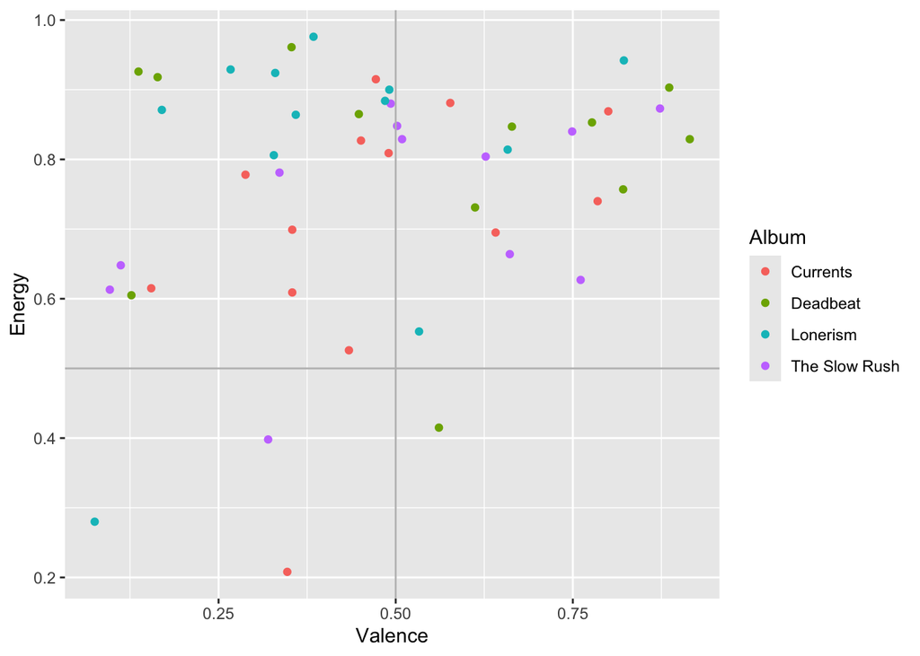

```r
# Making a scatterplot which shows each song from all the albums, labeled by color to distinguish the albums, showcasing Valence and Energy.
ggplot(df, aes(x = Valence, y = Energy, color = Album)) +
  geom_point() +
  geom_hline(yintercept = 0.5, color = "grey") +
  geom_vline(xintercept = 0.5, color = "grey")
```

This study will not study why these emotions in songs helps me study, that is a recommendation for another study. For now, I’m interested in the liveness and danceability of the songs from Tame Impala, to further see what kind of music helps me study.

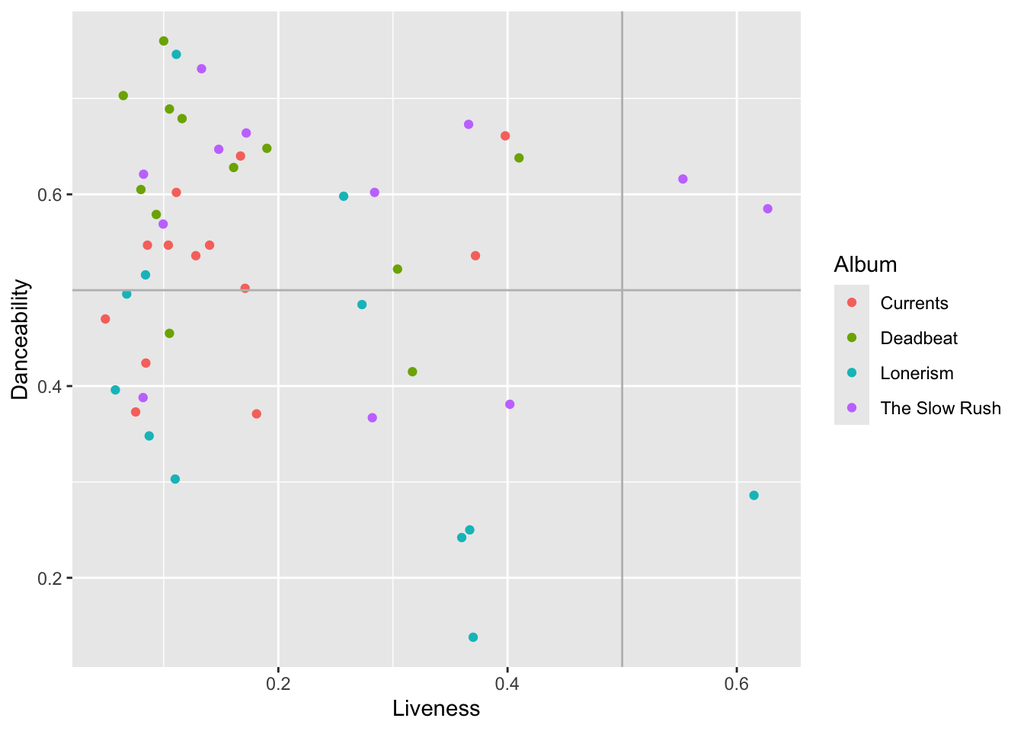

```r
# Making a scatterplot which shows each song from all the albums, labeled by color to distinguish the albums, showcasing Liveness and Danceability.
ggplot(df, aes(x = Liveness, y = Danceability, color = Album)) +
  geom_point() +
  geom_hline(yintercept = 0.5, color = "grey") +
  geom_vline(xintercept = 0.5, color = "grey")
```

To start, I expected that liveness was how “lively” the songs were, and my hypothesis was that the songs would represent my mood while studying, therefore being “unlively”. However, then I found out that liveness meant if there was an audience detected, which meant that my hypothesis was based on wrong assumptions. Even though that might be, the songs of Tame Impala do not have much liveness, while dancability is mixed but quite strong overall.

## Table

Now, lets see some variables in more detail using a table. It has been shown that songs from Tame Impala are high on energy. Let’s delve deeper into the other variable, valence. Therefore, lets look at the 5 songs with the highest valence.

```r
df |> slice_max(Valence, n=5) |> dplyr::select(Song, Album, Valence) |> knitr::kable(digits = 2)
```

| Song | Album | Valence |
| --- | --- | --- |
| Obsolete | Deadbeat | 0.92 |
| Afterthought | Deadbeat | 0.89 |
| Borderline | The Slow Rush | 0.87 |
| Mind Mischief | Lonerism | 0.82 |
| Loser | Deadbeat | 0.82 |

# Conclusion

Finally, I have found my answer! It seems like I like to study to songs with high energy and valence, as all of the songs that have the highest valence are songs that I frequent while studying. Therefore, this study has ‘concluded’ that songs with high energy and valence help me study. Another study can study why this kind of music helps me study, as this study is only the first step.